# TIRE vs Prime-seq barnyard

Daniel Brown

2025-02-04

# TIRE vs Prime-seq barnyard

## Aim

Investigate the difference between species separation in barnyard plots

## Data to read in

I read in experiments where I spiked my own human and mouse cell lines; HEK293T and NIH3T3.

TIRE-seq / TurboCapture-seq [mouse DC expt][https://au-mynotebook.labarchives.com/share/Daniel_RnD_Projects/NDUzLjd8NjgxOTcvMzQ5L1RyZWVOb2RlLzEzMDk5NDU5MDZ8MTE1MS43]

- Prime-seq/ Minibulk v2. [Splicing experiment 1](https://au-mynotebook.labarchives.com/share/Daniel_RnD_Projects/NDUyLjQwMDAwMDAwMDAwMDAzfDY4MTk3LzM0OC9UcmVlTm9kZS8xNjc4OTU2MTQwfDExNDguMzk5OTk5OTk5OTk5OQ==)

## Read SCE and extract col data

```r
tire <- readRDS(here::here(
  "data/TIRE_dendritic_mouse/SCEs/", "DCs_Mixed_basic.sce.rds"))

tb_tire <- as_tibble(colData(tire))
tb_tire$Protocol <- "TIRE-seq"

# Keep only the 8 PCR samples as these performed best and had most reads
tb_tire <- tb_tire %>%
  filter(Researcher == "DB")

tb_tire$Species <- recode(tb_tire$Species,
                         "None" = "NTC")
```

Prime-seq/ minibulk v2. In this experiment replicate 3 had the Janjic et al., style of RT primer removal; 2 bead cleanups + exo treatment.  
The first 2 replicates inherit the RT removal of our old protocols. 1 exo treatment and 1 bead cleanup.

```r
mb2 <- readRDS("/stornext/Home/data/allstaff/b/brown.d/Projects/G000233_DRAC-Seq/data/MB2_Benchmarking/SCEs/benchmarking_expt1_basic.sce.rds")

mb_tb <- as_tibble(colData(mb2))
mb_tb$Protocol <- "Modified Prime-seq"

# Remove first replicate leaving only 1 replicate each of different primer removal stratgeises
mb_tb <- mb_tb %>%
  filter(Researcher == "DB") %>%
  filter(Plate_replicate == "Three") %>%
  filter(Biological_replicate == 1)
```

Combine the tibbles together for subsequent visualisation.

```r
keep_cols <- intersect(
  colnames(mb_tb),
  colnames(tb_tire)
)

tb <- rbind(
  mb_tb[,keep_cols],
  tb_tire[,keep_cols]
)
```

# Human and mouse mapping

Add a CPM column to make the scale easier to see.

```r
tb <- tb %>%
  group_by(Protocol) %>%
  mutate(
    mouse_CPM =  subsets_Mouse_sum / sum(sum) * 1e6,
    human_CPM =  subsets_Human_sum / sum(sum) * 1e6
  )
```

## Barnyard natural scale

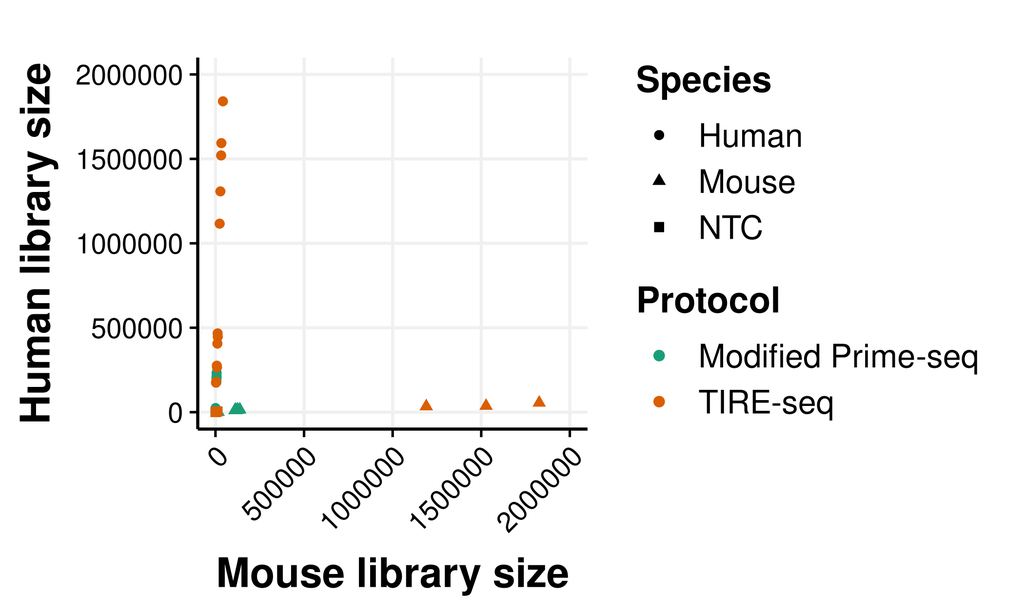

```r
p1 <- ggplot(tb, aes(x=subsets_Mouse_sum, y=subsets_Human_sum, colour=Protocol, shape=Species)) +
    geom_point(size=2) +
  xlab("Mouse library size") +
  ylab("Human library size") +
  ylim(0,2e6) + xlim(0,2e6) +
  scale_colour_brewer(palette = "Dark2")

p1
```

## Barnyard cpm scale

This is not very useful

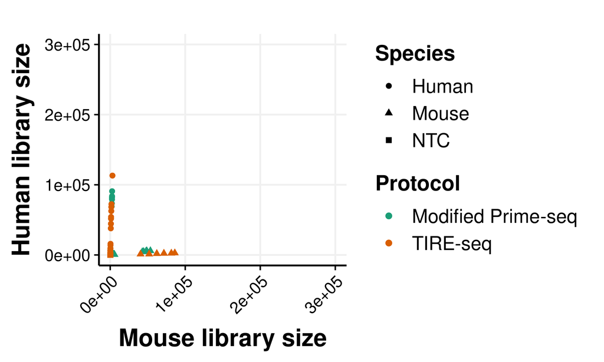

```r
p3 <- ggplot(tb, aes(x=mouse_CPM, y=human_CPM, colour=Protocol, shape=Species)) +
    geom_point(size=2) +
  xlab("Mouse library size") +
  ylab("Human library size") +
  ylim(0,3e5) + xlim(0,3e5) +
  scale_colour_brewer(palette = "Dark2")

p3
```

## Barnyard log scale

Probably the fairest looking comparison to have everything looking similar

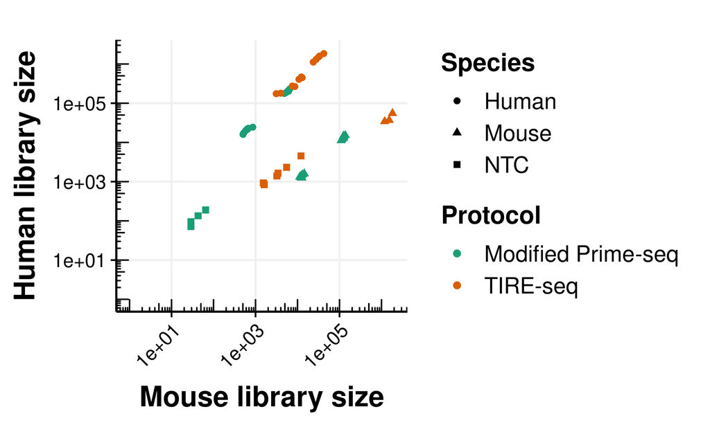

```r
p2 <- ggplot(tb, aes(y=subsets_Human_sum, x=subsets_Mouse_sum, colour=Protocol, shape=Species)) +
    geom_point(size=2) +
  xlab("Mouse library size") +
  ylab("Human library size") +
  scale_y_continuous(trans='log10', limits = c(1,2e6)) + scale_x_continuous(trans='log10', limits = c(1,2e6)) +
  annotation_logticks(base = 10, sides = "bl") +
  scale_colour_brewer(palette = "Dark2")

p2
```

## Violin percentages

Plotting the percent mapped also looks like a reasonable representation.

As there are fewer mouse samples in TIRE-Seq one would expect to see more bleed through of human into mousse which is not the case.

```r
percent <- tb %>%
  filter(Species != "NTC") %>%
  filter(Protocol != "Minimal primer removal") %>%
  select(Species, subsets_Human_percent, subsets_Mouse_percent, Protocol) %>%
  pivot_longer(cols = c(subsets_Human_percent, subsets_Mouse_percent), names_to = "Subset", values_to = "Percent")

percent$Subset <- recode(percent$Subset,
                         subsets_Human_percent = "Human",
                         subsets_Mouse_percent = "Mouse"
                         )
```

Produce the visualisation

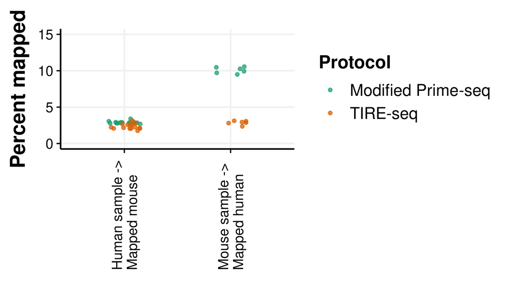

```r
filtered_tibble <- percent %>%
  filter((Species == "Mouse" & Subset == "Human") |
         (Species == "Human" & Subset == "Mouse"))

filtered_tibble$Subset <- recode(filtered_tibble$Subset,
                                 "Human" = "Mouse sample -> \nMapped human",
                                 "Mouse" = "Human sample -> \nMapped mouse")

# Modify the tibble to randomly sample 6 rows while keeping the rest
filtered_tibble <- filtered_tibble %>%
  group_by(Protocol, Subset) %>%
  mutate(
    selected = ifelse(Protocol == "Modified Prime-seq" & Subset == "Mouse sample -> \nMapped human",
                      row_number() %in% sample(row_number(), min(6, n())),
                      TRUE)  # Keep all other rows
  ) %>%
  ungroup() %>%
  filter(selected) %>%
  select(-selected)  # Remove the helper column

p5 <- ggplot(filtered_tibble, aes(y=Percent, x=Subset, colour=Protocol)) +
    geom_jitter(width = 0.15, alpha=0.75) +
  xlab("") +
  ylab("Percent mapped") + ylim(0,15) +
  theme(axis.text.x = element_text(angle = 90, vjust = 0.5, hjust = 0)) +
  scale_colour_brewer(palette = "Dark2")

p5
```

Look at the number of samples in each category

```r
filtered_tibble %>%
  group_by(Subset, Protocol) %>%
  count()
```

| Subset | Protocol | n |
| --- | --- | --- |
| Human sample -> \nMapped mouse | Modified Prime-seq | 15 |
| Human sample -> \nMapped mouse | TIRE-seq | 15 |
| Mouse sample -> \nMapped human | Modified Prime-seq | 6 |
| Mouse sample -> \nMapped human | TIRE-seq | 6 |